# Tandem Repeats in Colorectal Cancer

Characterization and Functional Analysis of Tandem Repeat

Matteo Delucchi

May 21, 2019

# Introduction

In Switzerland, colorectal cancer is among the top 3 leading cause for cancer-related mortality [1](https://www.krebsliga.ch/ueber-krebs/krebsarten/dickdarmkrebs/). As the disease shows varying clinical outcomes and therapeutic responses, researchers try through personalized medicine to find individually optimal treatments.

The development of colorectal cancer (CRC) is accompanied by genetic and epigenetic mutations in onco- and tumor-suppressor (unfavorable and favorable CRC) genes which are supposed to cause CRC onset, progression and metastasis [2](http://dx.doi.org/10.1155/2012/509348) [3](http://dx.doi.org/10.1136/flgastro-2013-100329).

Some clinical relevant biomarkers are today already used as prognostic and/or therapeutic predictive markers [4](https://doi.org/10.3892/or.2015.4108).

## Colorectal Cancer on a Molecular Level

Undifferentiated cells, such as colon stem progenitor cells, are located at the bottom of a crypt in healthy colons. They are able of self-renewal and pluripotency. During their life-cycle of about 14 days, they differentiate in all epithelial colon cell lineages (Paneth, goblet, enterocytes and enteroendocrine) while migrating from the crypt to the top of the villus leading into apoptosis [5](https://doi.org/10.1073/pnas.0707210104). The maintenance of genomic integrity is essential for proper cell differentiation in the colon. If it is lost, it’s easy to accumulate multiple mutations through chromosomal instability [6](https://doi.org/10.1053/j.gastro.2009.12.065), microsatellite instability [7](https://doi.org/10.1053/j.gastro.2009.12.064), aberrant DNA methylation 8 and/or DNA repair defects leading to CRC.

Several altered molecular signaling pathways are involved in CRC onset, such as Wnt/APC/$\beta$-catenin, phosphoinositide 3-kinase (PI3K)/AKT/glycogen synthase kinase-3$\beta$ (GSK-3$\beta$), transforming growth factor-$\beta$ (TGF)-$\beta$/Smad, NF- κb or mismatch repair genes (MMR) [9](https://doi.org/10.3892/or.2015.4108).

Wnt-signaling plays a key role in early cell fate decision in embryonic stem cells and is therefore under extensive investigation in cancer research. For example, the Wnt target gene *LGR5* is a multipotent stem cell marker in crypts. ASCL2, SOX9 and Paneth cell defensins are other examples of Wnt target genes controlling various steps in the differentiation process of stem cells.

### Wnt / $\beta$-catenin pathway

Upon secretion of Wnt ligand it binds to Frizzled (Fz) receptors. This results in the inactivation of the multifunctional kinase GSK-3$\beta$ and in the stabilisation of $\beta$-catenin. $\beta$-catenin is an E-cadherin cell-cell adhesion protein and transcriptional activator. If it is stabilized, it gets accumulated in the cytoplasm and is translocated into the nucleus. There it interacts with members of the lymphoid enhancer factor (LEF)/t-cell factor (TCF) and activates specific target genes. In absence of Wnt-signal, $\beta$-catenin is degradated preventing its nuclear translocation. The ubiquination and phosphorylation of $\beta$-catenin is controlled through casein kinase 1 (CK1) and the APC/Axin/GSK-3$\beta$-complex.

Activation of the Wnt pathway through mutations in the APC gene is known to have a leading role in CRC pathogenesis. The protein product of APC is among the key components of $\beta$-catenin destruction leading to an accumulation of $\beta$-catenin which is then translocated to the nucleus where it mediates gene transcription through interaction with the LEF/TCF transcription factor family (LEF-1/LEF1, TCF-1/TCF7, TCF-3/TCF7L1, and TCF-4/TCF7L2) [10](http://www.doi.org/10.4103/1477-3163.78111). The same outcome is expected, however, less frequently, through mutations in $\beta$-catenin and Axin2 [11](http://www.doi.org/10.1126/science.275.5307.1787) [12](https://doi.org/10.1038/79859)

An increased concentration of $\beta$-catenin in the cytoplasm promotes cellular proliferation. Nuclear expression of $\beta$-catenin can be identified immunohistochemically but is not a unique factor for CRC. However, it’s among one of the components of a diagnostic panel [13](https://doi.org/10.3892/or.2018.6330).

#### Wnt-Signaling and Colon Cancer

In different cancer types the $\beta$-catenin dependent pathway is differentially regulated in normal tissue compared to cancerous tissue and often shows $\beta$-catenin stabilizing mutations [14](https://doi.org/10.1101/gad.14.15.1837) [15](https://doi.org/10.1126/science.275.5307.1790) resulting in enhanced Wnt-signaling. Of many upstream and downstream components of $\beta$-catenin, APC and $\beta$-catenin are among the ones which show crucial roles in Wnt-signaling and cancer.

Looking at mouse models with activated Wnt-pathway through *APC* mutations, revealed that mutations in APC alone are not sufficient for carcinogenic development. The Apc<sup>min/+</sup> mouse models showed non-invasive intestinal tumors [16](https://dx.doi.org/10.1073%2Fpnas.94.25.13927). For unfavorable carcinoma development an increased activation of proto-oncogenetic signaling pathways (i.e. *K-ras*) and additional mutations in *TGFBRII*, *SMAD4*, *TP53* may be necessary 17.

Further, LEF/TCF transcription factors play a crucial role in CRC and may offer therapeutic opportunities [18](http://www.doi.org/10.4103/1477-3163.78111). The recruitment of $\beta$-catenin to target genes in Wnt-signaling is depending on a $\beta$-catenin binding domain at the N-terminus of the LEF/TCF transcription factor. At the C-terminus, a sequence-specific DNA binding domain recognize Wnt response elements in target genes. Interestingly, different LEF/TCF loci produce different protein isoforms through alternative splicing and different promotors which influence Wnt-signaling and can lead to cancer development [19](https://dx.doi.org/10.1101%2Fcshperspect.a007906) [20](https://doi.org/10.1038/sj.onc.1210056). The expression pattern of LEF/TCF loci varies between normal and cancerous human colon tissue. In healthy colon cells, TCF-1 and TCF-4 are expressed and LEF-1 and TCF-3 are silent. It could be shown in mouse models, that a loss of TCF-4 depeletes stem cells and eliminates cell proliferation in the intestine [21](https://doi.org/10.1038/1270). TCF-1 is suggested to be a feedback repressor of TCF-4 and cooperates with APC to suppress CRC. In cancerous colon cells, TCF-1 and TCF-4 are still expressed (eventhough now as a full-length form) but also LEF-1 is produced which results in a maximal $\beta$-catenin interaction and hence in oncogenic Wnt-signaling.

#### Short Tandem Repeats in Wnt-Pathway

We could show in 22 that TRs in proteins cluster to the flanks of protein sequences and are involved in protein-protein interactions as well as in transcription processes and DNA-binding. Therefore, we investigate if we can detect TRs with the state of the art classification method [23](https://dx.doi.org/10.1093%2Fnar%2Fgks726) in proteins generally associated with favorable and unfavorable CRC prognosis [24](https://www.proteinatlas.org/humanproteome/pathology/colorectal+cancer#colorectal%20cancerunfavourable) and in Wnt/$\beta$-catenin pathway related proteins with a focus on LEF/TCF transcription factors.

# Methods

## Data Sources and Collection

All protein sequences were retrieved via the REST API from UniProt/Swiss-Prot Knowledgebase [23](https://doi.org/10.1093/nar/gky1049) release 2019_04 for the reviewed entries of the Homo Sapiens proteome (UP000005640).

### Protein Sequence Origin

The names of CRC favorable and unfavorable genes were downloaded manually (Mai 2019) from the proteinatlas website [24](https://www.proteinatlas.org/humanproteome/pathology/colorectal+cancer#colorectal%20cancerunfavourable) and saved as .tsv. The sequences of proteins which are expressed from CRC favorable and unfavorable genes, were retreived from Swiss-Prot by querying all proteins from each gene. Next, we checked the .fasta file for duplicated protein IDs, which requiered manual inspection.

Analogously, the protein sequences for all proteins which are related to the Wnt-pathway in Swiss-Prot were retrieved and filtered for duplicates.

## Tandem Repeat Detection & Filtering

For the detection and filtering of TRs, we applied the open-source Python 3 Tandem Repeat Annotation Library (TRAL) [25](https://doi.org/10.1093/bioinformatics/btv306). *De novo* detection of TRs in protein sequences was performed applying the detectors HHrepID, T-REKS, TRUST and XSTREAM followed by a refinement with profile Hidden Markov Models (HMM) implemented with HMMER [26](https://doi.org/10.1093/bioinformatics/14.9.755) to capture most of the TR units and their boundaries. The TRs, were then filtered on a significance level of $\alpha = 0.05$ for a Likelyhood Ratio Test under the null hypothesis of random TR sequence evolution, a TR unit divergence of $d_{TR_{units}} < 0.1$ specifying the number of substitution site dating back to the most recent TR unit ancestor, a TR unit length of $l \leq 100$ specifying the number of noninsertion sites of the TR unit and a TR unit number of $n \geq 2.5$ specifying the number of noninsertion sites in the TR-MSA divided by $l$ [27](https://dx.doi.org/10.1093%2Fnar%2Fgks726).

### Processing TRAL Results for Data Mining in R

The detected TR characteristics and their MSA are stored for each protein in a single .tsv and binary .pickle file. For further analysis, we join the results for all proteins in one file for each group (unfavorable, favorable, Wnt-pathway) containing only proteins which have TRs.

The TR detection and annotation workflow is implemented in Python 3 and freely available on [Github](https://github.com/matteodelucchi/CRC_TRs.git). For reproduction of the reported results, change the code in order to use the provided datasets. To obtain the most recent datasets, just adapt `main.py` regarding your systems specification before sourcing.

## TR Characterization in CRC Associated Proteins

To provide a reproducible framework of the TR characterization the following results including the data of the previous section is implemented as an [R-package on github](https://github.com/matteodelucchi/TRAL-Result-Analysis.git) which can be installed like a regular R-package. Sourcing the vignette `GeneralOverviewofTandemRepeats.Rmd` allows an exact reproduction of the reported results.

The evaluation was performed using

```r
library(TRALResultAnalysis)
tr_crcfavorable_path <- paste0(base_path, "inst/extdata/TRs_favorable_proteins_CRC_sp_l100.tsv")
tr_crcunfavorable_path <- paste0(base_path, "inst/extdata/TRs_unfavorable_proteins_CRC_sp_l100.tsv")
tr_wnt_path <- paste0(base_path, "inst/extdata/TRs_Wnt_proteins_CRC_sp_l100.tsv")
dest_file_sp <- paste0(base_path, "data/swissprot_human.tsv")
dest_file_kin <- paste0(base_path, "data/swissprot_human_kinome.tsv")
```

To get deeper insights about the proteins containing TRs, more information is added from Swiss-Prot by a left join

```r
sp_url <- "https://www.uniprot.org/uniprot/?query=organism:%22Homo%20sapiens%20(Human)%20[9606]%22%20reviewed:yes&format=tab&columns=id,entry%20name,reviewed,protein%20names,genes,organism,length,virus%20hosts,encodedon,database(Pfam),interactor,comment(ABSORPTION),feature(ACTIVE%20SITE),comment(ACTIVITY%20REGULATION),feature(BINDING%20SITE),feature(CALCIUM%20BIND),comment(CATALYTIC%20ACTIVITY),comment(COFACTOR),feature(DNA%20BINDING),ec,comment(FUNCTION),comment(KINETICS),feature(METAL%20BINDING),feature(NP%20BIND),comment(PATHWAY),comment(PH%20DEPENDENCE),comment(REDOX%20POTENTIAL),rhea-id,feature(SITE),comment(TEMPERATURE%20DEPENDENCE)&sort=organism"

# Download the swissprot file only if it doesn't already exist.
# Uncomment this, if you want to use the most recent available data!
if(!file.exists(dest_file_sp)){
    download.file(sp_url, destfile = dest_file_sp)
}

sp_all_fav <- load_swissprot(dest_file_sp, tr_fav)
sp_all_unfav <- load_swissprot(dest_file_sp, tr_unfav)
sp_all_wnt <- load_swissprot(dest_file_sp, tr_wnt)

tr_unfav_sp <- merge(x = tr_unfav, y = sp_all_unfav, by = "ID", all.x = TRUE)
tr_fav_sp <- merge(x = tr_fav, y = sp_all_fav, by = "ID", all.x = TRUE)
tr_wnt_sp <- merge(x = tr_wnt, y = sp_all_wnt, by = "ID", all.x = TRUE)
```

# Results & Discussion

In 243 genes associated with unfavorable CRC expressing 286 proteins we could *de novo* detect 617 TRs of which after filtering and clustering 106 TRs remained. In CRC favorable genes (352) 403 proteins are expressed, where we could *de novo* detect 486 TRs with 50 TRs beeing left after filtering and clustering.

Additionally, 644 proteins were associated in Swiss-Prot with the Wnt-pathway, where we could *de novo* detect 1353 TRs of which 199 TRs remained after filtering and clustering.

## More TRs Were Detected in Proteins Associated With Unfavorable CRC Prognosis

```r
# CRC favorable
length(unique(tr_fav_sp$ID))/403 # through unique() we ensure to count those proteins with >1 TR only once.
```

```
#> [1] 0.09925558
```

```r
# CRC unfavorable
length(unique(tr_unfav_sp$ID))/286
```

```
#> [1] 0.2307692
```

```r
# Wnt pathway
length(unique(tr_wnt_sp$ID))
```

```
#> [1] 143
```

```r
length(unique(tr_wnt_sp$ID))/644
```

```
#> [1] 0.2220497
```

Of all proteins expressed by genes associated for beeing favorable or unfavorable for CRC, 10% and 23% contain at least one TR respectively. Analogously, we could detect TRs in 143 (22%) of the 644 proteins involved in the Human Wnt-pathway.

## Homo-TR Cluster Towards the N-Terminus

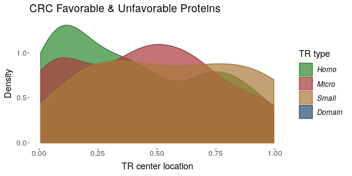

```r
TR_location(
  rbind(tr_fav_sp, tr_unfav_sp),
  plot_title = "CRC Favorable & Unfavorable Proteins",
  byTRtype = TRUE)
```

In proteins expressed from CRC favorable and unfavorable genes, homo-TRs show a tendency for N-terminal location. Many of the homo-TR fall in the region allocated to signal sequences which tags the proteins for extracellular translocation through the cell membrane.

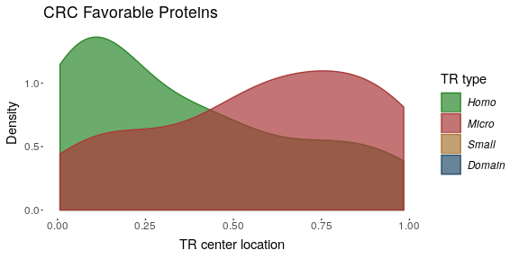

```r
TR_location(tr_fav_sp,
            plot_title = "CRC Favorable Proteins",
            byTRtype = TRUE)
```

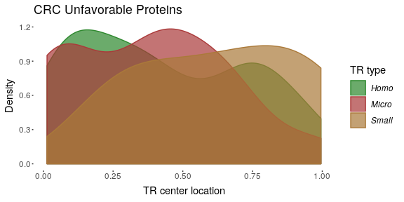

```r
TR_location(tr_unfav_sp,
            plot_title = "CRC Unfavorable Proteins",
            byTRtype = TRUE)
```

Looking seperately at CRC favorable and unfavorable proteins it can be observed that favorable CRC proteins have a greater tendency for N-terminal location of their homo-TRs. Which allows to hypothesize, that favorable CRC proteins may have a signal sequence and play extracellular roles more frequently than CRC unfavorable proteins.

It could be shown [TODO](https://doi.org/10.1111/j.1742-4658.2010.07720.x) that N-terminal signal peptides are rich in Leucine residues.

```r
# combine all TR from the three groups
tr_all <- rbind(tr_fav, tr_unfav, tr_wnt)

AAfreq_all <- AAfreq_in_TR(tr_all)
AAfreq_all[base::order(AAfreq_all$aa_ratio, decreasing = TRUE),]
```

```
#>   aa_freq aa aa_ratio
#> A     705  A   0.1429
#> S     614  S   0.1245
#> P     607  P   0.1231
#> G     484  G   0.0981
#> E     448  E   0.0908
#> Q     364  Q   0.0738
#> L     320  L   0.0649
#> T     281  T   0.0570
#> R     238  R   0.0483
#> K     190  K   0.0385
#> D     160  D   0.0324
#> H     130  H   0.0264
#> V     105  V   0.0213
#> I      88  I   0.0178
#> -      56  -   0.0114
#> N      47  N   0.0095
#> F      34  F   0.0069
#> Y      21  Y   0.0043
#> M      18  M   0.0036
#> C      17  C   0.0034
#> W       5  W   0.0010
#> U       0  U   0.0000
#> O       0  O   0.0000
#> B       0  B   0.0000
#> J       0  J   0.0000
#> Z       0  Z   0.0000
#> X       0  X   0.0000
#> *       0  *   0.0000
#> +       0  +   0.0000
#> .       0  .   0.0000
```

```r
AAfreq_all_homo <- AAfreq_in_TR(tr_all[which(tr_all$l_type == "homo"),])
AAfreq_all_homo[base::order(AAfreq_all_homo$aa_ratio, decreasing = TRUE),]
```

```
#>   aa_freq aa aa_ratio
#> A     390  A   0.1821
#> S     342  S   0.1597
#> E     319  E   0.1489
#> Q     255  Q   0.1190
#> P     232  P   0.1083
#> G     199  G   0.0929
#> L     167  L   0.0780
#> K      71  K   0.0331
#> H      58  H   0.0271
#> T      37  T   0.0173
#> D      35  D   0.0163
#> R      27  R   0.0126
#> C       6  C   0.0028
#> Y       2  Y   0.0009
#> N       1  N   0.0005
#> F       1  F   0.0005
#> I       0  I   0.0000
#> M       0  M   0.0000
#> W       0  W   0.0000
#> V       0  V   0.0000
#> U       0  U   0.0000
#> O       0  O   0.0000
#> B       0  B   0.0000
#> J       0  J   0.0000
#> Z       0  Z   0.0000
#> X       0  X   0.0000
#> *       0  *   0.0000
#> -       0  -   0.0000
#> +       0  +   0.0000
#> .       0  .   0.0000
```

```r
AAfreq_all[which(AAfreq_all$aa == "L"),]
```

```
#>   aa_freq aa aa_ratio
#> L     320  L   0.0649
```

```r
AAfreq_all_homo[which(AAfreq_all_homo$aa == "L"),]
```

```
#>   aa_freq aa aa_ratio
#> L     167  L    0.078
```

```r
# (AAfreq_fav <- AAfreq_in_TR(tr_fav))
# (AAfreq_unfav <- AAfreq_in_TR(tr_unfav))
# cor.test(AAfreq_fav$aa_ratio, AAfreq_unfav$aa_ratio, method = "spearman")
```

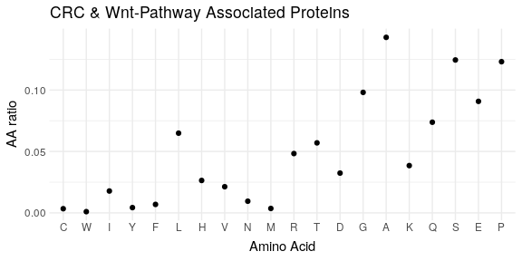

```r
AAratio_vs_Disorderpropensity(tr_all, plot_title = "CRC & Wnt-Pathway Associated Proteins")
```

Plotting the amino acid frequency ratio of TRs in CRC and Wnt-/$\beta$-catenin pathway associated proteins against the amino acid disorderpropensity we can see that more amino acids with high disorder propensity are part of TR in CRC and Wnt-/$\beta$-catenin pathway associated proteins - with exception of Lysine.

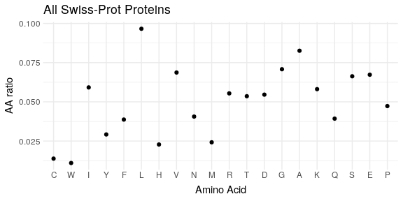

```r
AAratio_vs_Disorderpropensity(sp_overall = TRUE)
```

This trend is consistent with the overall amino acid frequency of all known proteins - amino acids with higher disorderpropensity appear in TRs significantly more frequent.

## Only Few Wnt-pathway Proteins Are Associated With CRC.

Proteins with TRs from the Wnt-pathway seem to be distinct from the proteins retrieved by genes.

```r
# CRC favorable proteins in Wnt pathway
tr_fav_sp$protein_name[which(tr_fav_sp$ID %in% tr_wnt_sp$ID)]
```

```
#> [1] "Mediator of RNA polymerase II transcription subunit 13-like (Mediator complex subunit 13-like) (Thyroid hormone receptor-associated protein 2) (Thyroid hormone receptor-associated protein complex 240 kDa component-like)"
#> [2] "CXXC-type zinc finger protein 5 (CF5) (Putative MAPK-activating protein PM08) (Putative NF-kappa-B-activating protein 102) (Retinoid-inducible nuclear factor) (RINF)"
#> [3] "DEP domain-containing protein 1B (HBV X-transactivated gene 8 protein) (HBV XAg-transactivated protein 8)"
```

3 Proteins which are associated with favorable CRC prognosis are involved in the Wnt-pathway and

```r
# CRC unfavorable proteins in Wnt pathway
tr_unfav_sp$protein_name[which(tr_unfav_sp$ID %in% tr_wnt_sp$ID)]
```

```
#> [1] "Nuclear factor of activated T-cells, cytoplasmic 4 (NF-ATc4) (NFATc4) (T-cell transcription factor NFAT3) (NF-AT3)"
#> [2] "Disabled homolog 2-interacting protein (DAB2 interaction protein) (DAB2-interacting protein) (ASK-interacting protein 1) (AIP-1) (DOC-2/DAB-2 interactive protein)"
#> [3] "Disabled homolog 2-interacting protein (DAB2 interaction protein) (DAB2-interacting protein) (ASK-interacting protein 1) (AIP-1) (DOC-2/DAB-2 interactive protein)"
#> [4] "Leucine zipper putative tumor suppressor 2 (hLZTS2) (Protein LAPSER1)"
#> [5] "Leucine zipper putative tumor suppressor 2 (hLZTS2) (Protein LAPSER1)"
```

## Nucleic Acid Binding Proteins Show Many Repeat Regions

The number of detected TRs exceeds the number of analysed proteins which suggests that there are proteins with more than one TR-region.

```r
# CRC favorable proteins
table(table(tr_fav$ID))
```

```
#>
#>  1  2  5
#> 33  6  1
```

```r
# CRC unfavorable proteins
table(table(tr_unfav_sp$ID))
```

```
#>
#>  1  2  3  4  5 11
#> 45 15  2  1  2  1
```

```r
# Wnt-pathway proteins
table(table(tr_wnt_sp$ID))
```

```
#>
#>   1   2   3   4
#> 102  28  11   2
```

Nevertheless, most of the proteins, contain only one TR-region we detect up to 11 different TR-regions i.e. in some CRC unfavorable associated proteins.

In proteins associated with unfavorable CRC prognosis we found in general more proteins with $\geq 4$ TRs compared to the group of unfavorable or Wnt-pathway proteins.

```r
protein_id_by_number_of_TR(tr_unfav_sp, 11)
```

```
#>      prot_id
#> [1,] "Q9H7N4"
```

```r
eleven_TRs <- tr_unfav_sp[which(tr_unfav_sp$ID == protein_id_by_number_of_TR(tr_unfav_sp, 11)[[1]]),]
unique(eleven_TRs$protein_name)
```

```
#> [1] "Splicing factor, arginine/serine-rich 19 (SR-related C-terminal domain-associated factor 1) (SR-related and CTD-associated factor 1) (SR-related-CTD-associated factor) (SCAF) (Serine arginine-rich pre-mRNA splicing factor SR-A1) (SR-A1)"
```

```r
unique(eleven_TRs$prot_function)
```

```
#> [1] "FUNCTION: May function in pre-mRNA splicing. {ECO:0000250}."
```

For example the splicing factor protein SFR19_HUMAN (ID: Q9H7N4) shows 11 TR-regions.

```r
protein_id_by_number_of_TR(tr_unfav_sp, 5)
```

```
#>      prot_id
#> [1,] "Q12948"
#> [2,] "Q8N2M8"
```

```r
five_TRs <- tr_unfav_sp[which(tr_unfav_sp$ID == protein_id_by_number_of_TR(tr_unfav_sp, 5)[1]),]
unique(five_TRs$protein_name)
```

```
#> [1] "Forkhead box protein C1 (Forkhead-related protein FKHL7) (Forkhead-related transcription factor 3) (FREAC-3)"
```

```r
unique(five_TRs$prot_function)
```

```
#> [1] "FUNCTION: DNA-binding transcriptional factor that plays a role in a broad range of cellular and developmental processes such as eye, bones, cardiovascular, kidney and skin development (PubMed:11782474, PubMed:15299087, PubMed:15684392, PubMed:16492674, PubMed:27907090, PubMed:14506133, PubMe…
```

```r
five_TRs <- tr_unfav_sp[which(tr_unfav_sp$ID == protein_id_by_number_of_TR(tr_unfav_sp, 5)[2]),]
unique(five_TRs$protein_name)
```

```
#> [1] "CLK4-associating serine/arginine rich protein (Splicing factor, arginine/serine-rich 16) (Suppressor of white-apricot homolog 2)"
```

```r
unique(five_TRs$prot_function)
```

```
#> [1] "FUNCTION: Probably functions as an alternative splicing regulator. May regulate the mRNA splicing of genes such as CLK1. May act by regulating members of the CLK kinase family (By similarity). {ECO:0000250}."
```

And Forkhead-related transcription factor 3 (ID: Q12948) and CLK4 splicing factor appear to have 5 TR-regions where the former is promoting cell growth inhibition and is involved in cell migration.

## Pathogenic Tandem Repeat Types Prevail

```r
summary(tr_fav_sp$l_effective)
```

```
#>    Min. 1st Qu.  Median    Mean 3rd Qu.    Max.
#>    1.00    1.00    1.00    1.88    2.00   28.00
```

```r
unique(tr_fav_sp$l_type)
```

```
#> [1] "homo"   "micro"  "domain" "small"
```

```r
summary(tr_unfav_sp$l_effective)
```

```
#>    Min. 1st Qu.  Median    Mean 3rd Qu.    Max.
#>   1.000   1.000   1.000   1.642   2.000   8.000
```

```r
unique(tr_unfav_sp$l_type)
```

```
#> [1] "homo"  "micro" "small"
```

```r
summary(tr_wnt_sp$l_effective)
```

```
#>    Min. 1st Qu.  Median    Mean 3rd Qu.    Max.
#>   1.000   1.000   1.000   2.156   1.000  76.000
```

```r
unique(tr_wnt_sp$l_type)
```

```
#> [1] "homo"   "micro"  "domain" "small"
```

In all three groups of proteins we could detect homo- micro- and small TRs of which homo- and micro-TRs are well known to be disease causing. We could further find domain-TR in CRC favorable proteins and in proteins associated to the Wnt-pathway.

```r
summary(tr_fav_sp$n_effective)
```

```
#>    Min. 1st Qu.  Median    Mean 3rd Qu.    Max.
#>    2.50    4.00    6.00    7.05    8.00   27.00
```

```r
summary(tr_unfav_sp$n_effective)
```

```
#>    Min. 1st Qu.  Median    Mean 3rd Qu.    Max.
#>   2.667   4.000   6.000   6.877   8.000  20.000
```

```r
summary(tr_wnt_sp$n_effective)
```

```
#>    Min. 1st Qu.  Median    Mean 3rd Qu.    Max.
#>   2.750   6.000   6.000   7.357   8.000  43.200
```

```r
summary(tr_fav_sp$total_repeat_length)
```

```
#>    Min. 1st Qu.  Median    Mean 3rd Qu.    Max.
#>    6.00    6.00    7.00    9.64    9.00   70.00
```

```r
summary(tr_unfav_sp$total_repeat_length)
```

```
#>    Min. 1st Qu.  Median    Mean 3rd Qu.    Max.
#>   6.000   6.000   8.000   9.387  10.000  53.000
```

```r
summary(tr_wnt_sp$total_repeat_length)
```

```
#>    Min. 1st Qu.  Median    Mean 3rd Qu.    Max.
#>    6.00    6.00    7.00   17.07    9.00  864.00
```

All TR-regions have a mean number of repeat units of 7 units per TR-region. The mean TR-region length of CRC associated proteins is about 9 amino acids in a range of 6 up to 70 and 53 for CRC favorable and unfavorable proteins respectively. In Wnt-pathway related proteins we could detect a mean repeat unit number of 7 and a TR-region length of 17 ranging from 6 to 864 amino acids.

```r
tr_wnt_sp[which(tr_wnt_sp$total_repeat_length == max(tr_wnt_sp$total_repeat_length)),]
```

```
#>        ID begin
#> 37 P15941    98
#>                                                                                                                                                                                                                                                                                                          …
#> 37 VTSVPVTRPALGSTTPPAHD,VTSAPDNKPAPGSTAPPAHG,VTSAPDTRPAPGSTAPPAHG,VTSAPDTRPAPGSTAPPAHG,VTSAPDTRPAPGSTAPPAHG,VTSAPDTRPAPGSTAPPAHG,VTSAPDTRPAPGSTAPPAHG,VTSAPDTRPAPGSTAPPAHG,VTSAPDTRPAPGSTAPPAHG,VTSAPDTRPAPGSTAPPAHG,VTSAPDTRPAPGSTAPPAHG,VTSAPDTRPAPGSTAPPAHG,VTSAPDTRPAPGSTAPPAHG,VTSAPDTRPAPGSTAPPAHG,…
#>    l_effective n_effective repeat_region_length divergence pvalue
#> 37          20        43.2                  864 0.01525879      0
#>    total_repeat_length center l_type  prot_name   Status
#> 37                 864  529.5 domain MUC1_HUMAN reviewed
#>                                                                                                                                                                                                                                                                                                          …
#> 37 Mucin-1 (MUC-1) (Breast carcinoma-associated antigen DF3) (Cancer antigen 15-3) (CA 15-3) (Carcinoma-associated mucin) (Episialin) (H23AG) (Krebs von den Lungen-6) (KL-6) (PEMT) (Peanut-reactive urinary mucin) (PUM) (Polymorphic epithelial mucin) (PEM) (Tumor-associated epithelial membrane ant…
#>    gene_names             Organism Length virus_hosts gene_encoded_by
#> 37   MUC1 PUM Homo sapiens (Human)   1255          NA
#>     PFAM_ID                                   interacts_with Absorption
#> 37 PF01390; P00519; P17676; P00533; P08581; P15941-7; P26368
#>    active_site activity_regulation binding_site calcium_binding
#> 37
#>    catalytic_activity Cofactor dna_binding EC_num
#> 37
#>                                                                                                                                                                                                                                                                                                          …
#> 37 FUNCTION: The alpha subunit has cell adhesive properties. Can act both as an adhesion and an anti-adhesion protein. May provide a protective layer on epithelial cells against bacterial and enzyme attack.; FUNCTION: The beta subunit contains a C-terminal domain which is involved in cell signali…
#>    Kinetics metal_binding nucleotide_binding Pathway pH_dependence
#> 37
#>    redox_potential Rhea_Ids                                   Site
#> 37                          SITE 1097 1098 Cleavage; by autolysis.
#>    temp_dependence has_tr has_homo_tr has_micro_tr has_short_tr
#> 37                   TRUE       FALSE        FALSE         TRUE
#>    has_domain_tr
#> 37          TRUE
```

```r
tr_wnt_sp$protein_name[which(tr_wnt_sp$total_repeat_length > 15)]
```

```
#>  [1] "Forkhead box protein E1 (Forkhead box protein E2) (Forkhead-related protein FKHL15) (HFKH4) (HNF-3/fork head-like protein 5) (HFKL5) (Thyroid transcription factor 2) (TTF-2)"
#>  [2] "Polyubiquitin-B [Cleaved into: Ubiquitin]"
#>  [3] "Polyubiquitin-C [Cleaved into: Ubiquitin]"
#>  [4] "Mucin-1 (MUC-1) (Breast carcinoma-associated antigen DF3) (Cancer antigen 15-3) (CA 15-3) (Carcinoma-associated mucin) (Episialin) (H23AG) (Krebs von den Lungen-6) (KL-6) (PEMT) (Peanut-reactive urinary mucin) (PUM) (Polymorphic epithelial mucin) (PEM) (Tumor-associated epithelial membrane …
#>  [5] "Protein AF-9 (ALL1-fused gene from chromosome 9 protein) (Myeloid/lymphoid or mixed-lineage leukemia translocated to chromosome 3 protein) (YEATS domain-containing protein 3)"
#>  [6] "Transcription activator BRG1 (EC 3.6.4.-) (ATP-dependent helicase SMARCA4) (BRG1-associated factor 190A) (BAF190A) (Mitotic growth and transcription activator) (Protein BRG-1) (Protein brahma homolog 1) (SNF2-beta) (SWI/SNF-related matrix-associated actin-dependent regulator of chromatin su…
#>  [7] "La-related protein 1 (La ribonucleoprotein domain family member 1)"
#>  [8] "Mediator of RNA polymerase II transcription subunit 12 (Activator-recruited cofactor 240 kDa component) (ARC240) (CAG repeat protein 45) (Mediator complex subunit 12) (OPA-containing protein) (Thyroid hormone receptor-associated protein complex 230 kDa component) (Trap230) (Trinucleotide re…
#>  [9] "Mediator of RNA polymerase II transcription subunit 12 (Activator-recruited cofactor 240 kDa component) (ARC240) (CAG repeat protein 45) (Mediator complex subunit 12) (OPA-containing protein) (Thyroid hormone receptor-associated protein complex 230 kDa component) (Trap230) (Trinucleotide re…
#> [10] "Probable E3 ubiquitin-protein ligase IRF2BPL (EC 2.3.2.27) (Enhanced at puberty protein 1) (Interferon regulatory factor 2-binding protein-like)"
#> [11] "WD repeat-containing protein 26 (CUL4- and DDB1-associated WDR protein 2) (Myocardial ischemic preconditioning up-regulated protein 2)"
#> [12] "Microtubule-actin cross-linking factor 1, isoforms 1/2/3/5 (620 kDa actin-binding protein) (ABP620) (Actin cross-linking family protein 7) (Macrophin-1) (Trabeculin-alpha)"
```

```r
unique(tr_wnt_sp$prot_function[which(tr_wnt_sp$total_repeat_length > 15)])
```

```
#>  [1] "FUNCTION: Transcription factor that binds consensus sites on a variety of gene promoters and activate their transcription. Involved in proper palate formation, most probably through the expression of MSX1 and TGFB3 genes which are direct targets of this transcription factor. Also implicated…
#>  [2] "FUNCTION: Ubiquitin: Exists either covalently attached to another protein, or free (unanchored). When covalently bound, it is conjugated to target proteins via an isopeptide bond either as a monomer (monoubiquitin), a polymer linked via different Lys residues of the ubiquitin (polyubiquitin…
#>  [3] "FUNCTION: The alpha subunit has cell adhesive properties. Can act both as an adhesion and an anti-adhesion protein. May provide a protective layer on epithelial cells against bacterial and enzyme attack.; FUNCTION: The beta subunit contains a C-terminal domain which is involved in cell sign…
#>  [4] "FUNCTION: Chromatin reader component of the super elongation complex (SEC), a complex required to increase the catalytic rate of RNA polymerase II transcription by suppressing transient pausing by the polymerase at multiple sites along the DNA (PubMed:20159561, PubMed:20471948, PubMed:25417…
#>  [5] "FUNCTION: Involved in transcriptional activation and repression of select genes by chromatin remodeling (alteration of DNA-nucleosome topology). Component of SWI/SNF chromatin remodeling complexes that carry out key enzymatic activities, changing chromatin structure by altering DNA-histone …
#>  [6] "FUNCTION: RNA-binding protein that regulates the translation of specific target mRNA species downstream of the mTORC1 complex, in function of growth signals and nutrient availability (PubMed:20430826, PubMed:23711370, PubMed:24532714, PubMed:25940091, PubMed:28650797, PubMed:28673543, PubMe…
#>  [7] "FUNCTION: Component of the Mediator complex, a coactivator involved in the regulated transcription of nearly all RNA polymerase II-dependent genes. Mediator functions as a bridge to convey information from gene-specific regulatory proteins to the basal RNA polymerase II transcription machin…
#>  [8] "FUNCTION: Probable E3 ubiquitin protein ligase involved in the proteasome-mediated ubiquitin-dependent degradation of target proteins (PubMed:29374064). Through the degradation of CTNNB1, functions downstream of FOXF2 to negatively regulate the Wnt signaling pathway (PubMed:29374064). Proba…
#>  [9] "FUNCTION: G-beta-like protein involved in cell signal transduction (PubMed:15378603, PubMed:19446606, PubMed:22065575, PubMed:23625927, PubMed:27098453, PubMed:26895380). Acts as a negative regulator in MAPK signaling pathway (PubMed:15378603). Functions as a scaffolding protein to promote …
#> [10] "FUNCTION: Isoform 2: F-actin-binding protein which plays a role in cross-linking actin to other cytoskeletal proteins and also binds to microtubules (PubMed:15265687, PubMed:20937854). Plays an important role in ERBB2-dependent stabilization of microtubules at the cell cortex (PubMed:209378…
```

Wnt-pathway associated proteins with long TR-regions are generally involved in transcriptional regulation. But also others, such as the WD repeat-containing protein 26 which negatively regulated the Wnt-pathway contains long repeat regions.

```r
tr_fav_sp$protein_name[which(tr_fav_sp$total_repeat_length > 15)]
```

```
#> [1] "Serine/arginine-rich splicing factor 1 (Alternative-splicing factor 1) (ASF-1) (Splicing factor, arginine/serine-rich 1) (pre-mRNA-splicing factor SF2, P33 subunit)"
#> [2] "Vascular endothelial zinc finger 1 (Putative transcription factor DB1) (Zinc finger protein 161)"
#> [3] "Zinc finger protein 792"
#> [4] "BMP-2-inducible protein kinase (BIKe) (EC 2.7.11.1)"
```

```r
unique(tr_fav_sp$prot_function[which(tr_fav_sp$total_repeat_length > 15)])
```

```
#> [1] "FUNCTION: Plays a role in preventing exon skipping, ensuring the accuracy of splicing and regulating alternative splicing. Interacts with other spliceosomal components, via the RS domains, to form a bridge between the 5'- and 3'-splice site binding components, U1 snRNP and U2AF. Can stimulat…
#> [2] "FUNCTION: Possible transcription factor. Specifically binds to the CT/GC-rich region of the interleukin-3 promoter and mediates tax transactivation of IL-3. {ECO:0000269|PubMed:8035792}."
#> [3] "FUNCTION: May be involved in transcriptional regulation."
#> [4] "FUNCTION: May be involved in osteoblast differentiation."
```

Similarly proteins associated with favorable prognosis of CRC containing long TR-regions show beside transcriptional regulatory functions also roles in regulation of alternative splicing.

```r
tr_unfav_sp$protein_name[which(tr_unfav_sp$total_repeat_length > 15)]
```

```
#> [1] "Major prion protein (PrP) (ASCR) (PrP27-30) (PrP33-35C) (CD antigen CD230)"
#> [2] "ATP-sensitive inward rectifier potassium channel 8 (Inward rectifier K(+) channel Kir6.1) (Potassium channel, inwardly rectifying subfamily J member 8) (uKATP-1)"
#> [3] "TBC1 domain family member 10B (Rab27A-GAP-beta)"
#> [4] "Membrane-associated guanylate kinase, WW and PDZ domain-containing protein 2 (Atrophin-1-interacting protein 1) (AIP-1) (Atrophin-1-interacting protein A) (Membrane-associated guanylate kinase inverted 2) (MAGI-2)"
#> [5] "Membrane-associated guanylate kinase, WW and PDZ domain-containing protein 1 (Atrophin-1-interacting protein 3) (AIP-3) (BAI1-associated protein 1) (BAP-1) (Membrane-associated guanylate kinase inverted 1) (MAGI-1) (Trinucleotide repeat-containing gene 19 protein) (WW domain-containing prote…
#> [6] "Splicing factor, arginine/serine-rich 19 (SR-related C-terminal domain-associated factor 1) (SR-related and CTD-associated factor 1) (SR-related-CTD-associated factor) (SCAF) (Serine arginine-rich pre-mRNA splicing factor SR-A1) (SR-A1)"
#> [7] "Protein WWC3"
#> [8] "Numb-like protein (Numb-related protein) (Numb-R)"
```

```r
unique(tr_unfav_sp$prot_function[which(tr_unfav_sp$total_repeat_length > 15)])
```

```
#> [1] "FUNCTION: Its primary physiological function is unclear. May play a role in neuronal development and synaptic plasticity. May be required for neuronal myelin sheath maintenance. May promote myelin homeostasis through acting as an agonist for ADGRG6 receptor. May play a role in iron uptake an…
#> [2] "FUNCTION: This potassium channel is controlled by G proteins. Inward rectifier potassium channels are characterized by a greater tendency to allow potassium to flow into the cell rather than out of it. Their voltage dependence is regulated by the concentration of extracellular potassium; as …
#> [3] "FUNCTION: Acts as GTPase-activating protein for RAB3A, RAB22A, RAB27A, AND RAB35. Does not act on RAB2A and RAB6A. {ECO:0000269|PubMed:16923811, ECO:0000269|PubMed:19077034}."
#> [4] "FUNCTION: Seems to act as scaffold molecule at synaptic junctions by assembling neurotransmitter receptors and cell adhesion proteins. May play a role in regulating activin-mediated signaling in neuronal cells. Enhances the ability of PTEN to suppress AKT1 activation. Plays a role in nerve g…
#> [5] "FUNCTION: May play a role as scaffolding protein at cell-cell junctions. May regulate acid-induced ASIC3 currents by modulating its expression at the cell surface (By similarity). {ECO:0000250}."
#> [6] "FUNCTION: May function in pre-mRNA splicing. {ECO:0000250}."
#> [7] ""
#> [8] "FUNCTION: Plays a role in the process of neurogenesis. Required throughout embryonic neurogenesis to maintain neural progenitor cells, also called radial glial cells (RGCs), by allowing their daughter cells to choose progenitor over neuronal cell fate. Not required for the proliferation of n…
```

Interestingly, the Numb-like protein (ID: Q9Y6R0, Numbl) contains a long (20 AA) poly-Q homo-TR. Its interaction through NF-$\kappa$-B upregulates Lef1-expression which enhances transcriptional activity of TCF/LEF [REF](https://dx.doi.org/10.3389%2Ffimmu.2016.00378).

## Binding of LEF/TCF to $\beta$-Catenin is Mediated Through Tandem Repeats

```r
# Show only a selection of variables
sel_var <- c("ID", "begin", "msa_original", "repeat_region_length", "l_type", "prot_name", "protein_name", "gene_names", "prot_function")
tr_wnt_sp[which(tr_wnt_sp$ID == "Q9UJU2"),sel_var]
```

```
#>         ID begin    msa_original repeat_region_length l_type  prot_name
#> 184 Q9UJU2     6 G,G,G,G,G,G,G,G                    8   homo LEF1_HUMAN
#>                                                                                               protein_name
#> 184 Lymphoid enhancer-binding factor 1 (LEF-1) (T cell-specific transcription factor 1-alpha) (TCF1-alpha)
#>     gene_names
#> 184       LEF1
#>                                                                                                                                                                                                                                                                                                          …
#> 184 FUNCTION: Participates in the Wnt signaling pathway. Activates transcription of target genes in the presence of CTNNB1 and EP300. May play a role in hair cell differentiation and follicle morphogenesis. TLE1, TLE2, TLE3 and TLE4 repress transactivation mediated by LEF1 and CTNNB1. Regulates T…
```

In LEF1 we found a significant poly-G TR-region at the N-terminal end which falls in the binding region with $\beta$-catenin1 (positions 1-66 based on similarity [TODO](https://www.uniprot.org/uniprot/Q9UJU2#family_and_domains)).

```r
tr_wnt_sp[which(tr_wnt_sp$ID == "Q9HCS4"),sel_var]
```

```
#>         ID begin        msa_original repeat_region_length l_type
#> 165 Q9HCS4     5 G,G,G,G,G,G,G,G,G,G                   10   homo
#>       prot_name
#> 165 TF7L1_HUMAN
#>                                                               protein_name
#> 165 Transcription factor 7-like 1 (HMG box transcription factor 3) (TCF-3)
#>      gene_names
#> 165 TCF7L1 TCF3
#>                                                                                                                                                                                                                                                                                                          …
#> 165 FUNCTION: Participates in the Wnt signaling pathway. Binds to DNA and acts as a repressor in the absence of CTNNB1, and as an activator in its presence. Necessary for the terminal differentiation of epidermal cells, the formation of keratohyalin granules and the development of the barrier fun…
```

```r
tr_wnt_sp[which(tr_wnt_sp$ID == "P36402"),sel_var]
```

```
#>        ID begin msa_original repeat_region_length l_type  prot_name
#> 47 P36402    73     GA,GA,GA                    6  micro TCF7_HUMAN
#>                                                                                         protein_name
#> 47 Transcription factor 7 (TCF-7) (T-cell-specific transcription factor 1) (T-cell factor 1) (TCF-1)
#>    gene_names
#> 47  TCF7 TCF1
#>                                                                                                                                                                                                                                                                                                          …
#> 47 FUNCTION: Transcriptional activator involved in T-cell lymphocyte differentiation. Necessary for the survival of CD4(+) CD8(+) immature thymocytes. Isoforms lacking the N-terminal CTNNB1 binding domain cannot fulfill this role. Binds to the T-lymphocyte-specific enhancer element (5'-WWCAAAG-3'…
```

## $\beta$-Catenin Destruction Complex Not Only Relies On Tandem Repeats

The $\beta$-catenin destruction complex comprises different proteins, such as adenomatosis polyposis coli (APC), Axin, protein phosphatase (PP2A), glycogen synthase kinase 3 (GSK3) and casein kinase 1 (CK1).

### APC $\beta$-Catenin Binding Domain Contains Tandem Repeats

```r
tr_wnt_sp[grepl("APC", tr_wnt_sp$prot_name),sel_var]
```

```
#>        ID begin msa_original repeat_region_length l_type  prot_name
#> 27 O95996  1378     PA,PA,PA                    6  micro APCL_HUMAN
#> 28 O95996   841     AK,AK,AK                    6  micro APCL_HUMAN
#> 46 P25054  2763  S,S,S,S,S,S                    6   homo  APC_HUMAN
#>                                                                                 protein_name
#> 27 Adenomatous polyposis coli protein 2 (Adenomatous polyposis coli protein-like) (APC-like)
#> 28 Adenomatous polyposis coli protein 2 (Adenomatous polyposis coli protein-like) (APC-like)
#> 46               Adenomatous polyposis coli protein (Protein APC) (Deleted in polyposis 2.5)
#>    gene_names
#> 27  APC2 APCL
#> 28  APC2 APCL
#> 46  APC DP2.5
#>                                                                                                                                                                                                                                                                                                          …
#> 27                                                                                                                                                                                                                                                                                                       …
#> 28                                                                                                                                                                                                                                                                                                       …
#> 46 FUNCTION: Tumor suppressor. Promotes rapid degradation of CTNNB1 and participates in Wnt signaling as a negative regulator. APC activity is correlated with its phosphorylation state. Activates the GEF activity of SPATA13 and ARHGEF4. Plays a role in hepatocyte growth factor (HGF)-induced cell …
```

The polyS homo-TR region in the APC protein sequence was the only repeat region which could be detected, eventhough there are structurally verified armadillo repeats near the N-terminal end of the protein sequence. However, in the very similar APC-like protein, we could detect a micro-TR in a region associated with $\beta$-catenin binding necessary for its degradation [TODO](http://cancerres.aacrjournals.org/content/58/22/5176).

### GSK

```r
tr_wnt_sp[grepl("GSK", tr_wnt_sp$prot_name),sel_var]
```

```
#>        ID begin        msa_original repeat_region_length l_type
#> 50 P49840    26 G,G,G,G,G,G,G,G,G,G                   10   homo
#> 51 P49841   412            AS,AS,AS                    6  micro
#>      prot_name
#> 50 GSK3A_HUMAN
#> 51 GSK3B_HUMAN
#>                                                                                                           protein_name
#> 50 Glycogen synthase kinase-3 alpha (GSK-3 alpha) (EC 2.7.11.26) (Serine/threonine-protein kinase GSK3A) (EC 2.7.11.1)
#> 51   Glycogen synthase kinase-3 beta (GSK-3 beta) (EC 2.7.11.26) (Serine/threonine-protein kinase GSK3B) (EC 2.7.11.1)
#>    gene_names
#> 50      GSK3A
#> 51      GSK3B
#>                                                                                                                                                                                                                                                                                                          …
#> 50                                                                                                                                                                                                                                                                                                       …
#> 51 FUNCTION: Constitutively active protein kinase that acts as a negative regulator in the hormonal control of glucose homeostasis, Wnt signaling and regulation of transcription factors and microtubules, by phosphorylating and inactivating glycogen synthase (GYS1 or GYS2), EIF2B, CTNNB1/beta-cate…
```

In GSK3A and GSK3B we could detect a polyG homo-TR at N-terminal proximity and a micro TR near the C-terminus respectively.

### Casein Kinase I

```r
tr_wnt_sp[grepl("KC", tr_wnt_sp$prot_name),sel_var]
```

```
#> [1] ID                   begin                msa_original
#> [4] repeat_region_length l_type               prot_name
#> [7] protein_name         gene_names           prot_function
#> <0 rows> (or 0-length row.names)
```

```r
tr_fav_sp[grepl("KC", tr_fav_sp$prot_name),sel_var]
```

```
#> [1] ID                   begin                msa_original
#> [4] repeat_region_length l_type               prot_name
#> [7] protein_name         gene_names           prot_function
#> <0 rows> (or 0-length row.names)
```

```r
tr_unfav_sp[grepl("KC", tr_unfav_sp$prot_name),sel_var]
```

```
#>        ID begin                msa_original repeat_region_length l_type
#> 38 Q15842   384 NSMRRN,NSMRRN,NSIRRN,NS----                   20  small
#>      prot_name
#> 38 KCNJ8_HUMAN
#>                                                                                                                                                         protein_name
#> 38 ATP-sensitive inward rectifier potassium channel 8 (Inward rectifier K(+) channel Kir6.1) (Potassium channel, inwardly rectifying subfamily J member 8) (uKATP-1)
#>    gene_names
#> 38      KCNJ8
#>                                                                                                                                                                                                                                                                                                          …
#> 38 FUNCTION: This potassium channel is controlled by G proteins. Inward rectifier potassium channels are characterized by a greater tendency to allow potassium to flow into the cell rather than out of it. Their voltage dependence is regulated by the concentration of extracellular potassium; as ex…
```

With the applied filtering approach, no TRs were found in Casein kinase I isoform epsilon of Wnt-pathway associated or CRC favorable proteins. However, in the set of proteins CRC unfavorable, we found a small TR in the C-terminal cytoplasmic region of ATP-sensitive inward rectifier potassium channel 8 protein.

### Axin Offers A Prone Site For Tandem Repeat Disorder

```r
tr_wnt_sp[grepl("AXIN", tr_wnt_sp$prot_name),sel_var]
```

```
#>         ID begin msa_original repeat_region_length l_type   prot_name
#> 196 Q9Y2T1   469  H,H,H,H,H,H                    6   homo AXIN2_HUMAN
#>                                                                  protein_name
#> 196 Axin-2 (Axin-like protein) (Axil) (Axis inhibition protein 2) (Conductin)
#>     gene_names
#> 196      AXIN2
#>                                                                                                                                                                                prot_function
#> 196 FUNCTION: Inhibitor of the Wnt signaling pathway. Down-regulates beta-catenin. Probably facilitate the phosphorylation of beta-catenin and APC by GSK3B. {ECO:0000250|UniProtKB:O15169}.
```

Mutations in AXIN1 and AXIN2 are involved with CRC pathogenesis [TODO](https://doi.org/10.1038/79859). In Axin-2 overlapping with the compositionally biased histidine region, a polyH homo-TR could be detected which falls in the region interacting with armadillo repeats in $\beta$-catenin.

TRD in this region may destabilize the binding of $\beta$-catenin to the protein-complex with Axin-2 resulting in an accumulation of $\beta$-catenin followed by a transcriptional activation of the Wnt/$\beta$-catenin target genes which is known to be a leading cause CRC.

## Dishevelled Proteins

```r
tr_wnt_sp[grepl("DVL", tr_wnt_sp$prot_name),sel_var]
```

```
#>       ID begin msa_original repeat_region_length l_type  prot_name
#> 4 O14641   686  P,P,P,P,P,P                    6   homo DVL2_HUMAN
#>                                                                         protein_name
#> 4 Segment polarity protein dishevelled homolog DVL-2 (Dishevelled-2) (DSH homolog 2)
#>   gene_names
#> 4       DVL2
#>                                                                                                                                                                                                                                                                                                          …
#> 4 FUNCTION: Plays a role in the signal transduction pathways mediated by multiple Wnt genes. Participates both in canonical and non-canonical Wnt signaling by binding to the cytoplasmic C-terminus of frizzled family members and transducing the Wnt signal to down-stream effectors. Promotes interna…
```

Dishevelled proteins bind to the C-terminus of frizzeled proteins promoting their internalisation upon Wnt-signaling [TODO](http://dx.doi.org/10.1038/nchembio.152). DVL-2 shows a polyP homo-TR near it’s C-terminal end which could to our knowledge not be brought in contribution with Frizzled-binding.

FOXK1 and FOXK2 are positively transcriptionally regulating the Wnt-pathway and interact with DVL proteins. FOXK1/2 are reported to be highly expressed in CRC and correlate with nuclear localisation of DVL proteins [TODO](https://doi.org/10.1016/j.devcel.2015.01.031).

```r
tr_wnt_sp[grepl("FOX", tr_wnt_sp$prot_name),sel_var]
```

```
#>        ID begin                    msa_original repeat_region_length
#> 2  O00358   164 A,A,A,A,A,A,A,A,A,A,A,A,A,A,A,A                   16
#> 61 P85037    27                   A,A,A,A,A,A,A                    7
#> 62 P85037   690                        AS,AS,AS                    6
#> 63 Q01167     2                     A,A,A,A,A,A                    6
#> 64 Q01167   608                        AS,AS,AS                    6
#> 77 Q12778    90                  VAAA,VAAA,AAAA                   12
#>    l_type   prot_name
#> 2    homo FOXE1_HUMAN
#> 61   homo FOXK1_HUMAN
#> 62  micro FOXK1_HUMAN
#> 63   homo FOXK2_HUMAN
#> 64  micro FOXK2_HUMAN
#> 77  small FOXO1_HUMAN
#>                                                                                                                                                                     protein_name
```

[output cut: 20 more lines]

```r
tr_fav_sp[grepl("FOX", tr_fav_sp$prot_name),sel_var]
```

```
#> [1] ID                   begin                msa_original
#> [4] repeat_region_length l_type               prot_name
#> [7] protein_name         gene_names           prot_function
#> <0 rows> (or 0-length row.names)
```

```r
tr_unfav_sp[grepl("FOX", tr_unfav_sp$prot_name),sel_var]
```

```
#>        ID begin        msa_original repeat_region_length l_type
#> 27 Q12948   438         S,S,S,S,S,S                    6   homo
#> 28 Q12948   447 G,G,G,G,G,G,G,G,G,G                   10   homo
#> 29 Q12948   375         G,G,G,G,G,G                    6   homo
#> 30 Q12948   488     A,A,A,A,A,A,A,A                    8   homo
#> 31 Q12948    28         A,A,A,A,A,A                    6   homo
#>      prot_name
#> 27 FOXC1_HUMAN
#> 28 FOXC1_HUMAN
#> 29 FOXC1_HUMAN
#> 30 FOXC1_HUMAN
#> 31 FOXC1_HUMAN
#>                                                                                                    protein_name
#> 27 Forkhead box protein C1 (Forkhead-related protein FKHL7) (Forkhead-related transcription factor 3) (FREAC-3)
#> 28 Forkhead box protein C1 (Forkhead-related protein FKHL7) (Forkhead-related transcription factor 3) (FREAC-3)
#> 29 Forkhead box protein C1 (Forkhead-related protein FKHL7) (Forkhead-related transcription factor 3) (FREAC-3)
#> 30 Forkhead box protein C1 (Forkhead-related protein FKHL7) (Forkhead-related transcription factor 3) (FREAC-3)
#> 31 Forkhead box protein C1 (Forkhead-related protein FKHL7) (Forkhead-related transcription factor 3) (FREAC-3)
#>            gene_names
#> 27 FOXC1 FKHL7 FREAC3
#> 28 FOXC1 FKHL7 FREAC3
#> 29 FOXC1 FKHL7 FREAC3
#> 30 FOXC1 FKHL7 FREAC3
#> 31 FOXC1 FKHL7 FREAC3
#>                                                                                                                                                                                                                                                                                                          …
#> 27 FUNCTION: DNA-binding transcriptional factor that plays a role in a broad range of cellular and developmental processes such as eye, bones, cardiovascular, kidney and skin development (PubMed:11782474, PubMed:15299087, PubMed:15684392, PubMed:16492674, PubMed:27907090, PubMed:14506133, PubMed:…
#> 28 FUNCTION: DNA-binding transcriptional factor that plays a role in a broad range of cellular and developmental processes such as eye, bones, cardiovascular, kidney and skin development (PubMed:11782474, PubMed:15299087, PubMed:15684392, PubMed:16492674, PubMed:27907090, PubMed:14506133, PubMed:…
#> 29 FUNCTION: DNA-binding transcriptional factor that plays a role in a broad range of cellular and developmental processes such as eye, bones, cardiovascular, kidney and skin development (PubMed:11782474, PubMed:15299087, PubMed:15684392, PubMed:16492674, PubMed:27907090, PubMed:14506133, PubMed:…
#> 30 FUNCTION: DNA-binding transcriptional factor that plays a role in a broad range of cellular and developmental processes such as eye, bones, cardiovascular, kidney and skin development (PubMed:11782474, PubMed:15299087, PubMed:15684392, PubMed:16492674, PubMed:27907090, PubMed:14506133, PubMed:…
#> 31 FUNCTION: DNA-binding transcriptional factor that plays a role in a broad range of cellular and developmental processes such as eye, bones, cardiovascular, kidney and skin development (PubMed:11782474, PubMed:15299087, PubMed:15684392, PubMed:16492674, PubMed:27907090, PubMed:14506133, PubMed:…
```

Forkhead box protein C1 (FOXC1) in contrast is part of the CRC unfavorable associated proteins. FOXC1 acts as a transcriptional activator where the crucial domains are located at the C- and N-termini. Most of the detected TRs fall exactely in these regions responsible for transcriptional activation [TODO](https://doi.org/10.1074/jbc.M110266200). The C-terminal end 366-553 is the proposed binding region of a degradation factor [TODO](https://doi.org/10.1074/jbc.M513629200) and the region 47-553 could be shown to bind to PITX2 [TODO](https://doi.org/10.1093/hmg/ddl008) supporting the idea of TRs acting as keyplayers in protein-protein interactions. To our knowledge, no structural interaction data is available to further prove this hypothesis.

Interestingly, in both FOXK and FOXC proteins the forkhead box didn’t show any TRs - they are rather clustered around the forkhead box.

```r
tr_wnt_sp[which(tr_wnt_sp$ID == "O00358"),sel_var]
```

```
#>       ID begin                    msa_original repeat_region_length l_type
#> 2 O00358   164 A,A,A,A,A,A,A,A,A,A,A,A,A,A,A,A                   16   homo
#>     prot_name
#> 2 FOXE1_HUMAN
#>                                                                                                                                                                    protein_name
#> 2 Forkhead box protein E1 (Forkhead box protein E2) (Forkhead-related protein FKHL15) (HFKH4) (HNF-3/fork head-like protein 5) (HFKL5) (Thyroid transcription factor 2) (TTF-2)
#>                      gene_names
#> 2 FOXE1 FKHL15 FOXE2 TITF2 TTF2
#>                                                                                                                                                                                                                                                                                                          …
#> 2 FUNCTION: Transcription factor that binds consensus sites on a variety of gene promoters and activate their transcription. Involved in proper palate formation, most probably through the expression of MSX1 and TGFB3 genes which are direct targets of this transcription factor. Also implicated in …
```

```r
tr_unfav_sp[which(tr_unfav_sp$ID == "P10070"),sel_var]
```

```
#> [1] ID                   begin                msa_original
#> [4] repeat_region_length l_type               prot_name
#> [7] protein_name         gene_names           prot_function
#> <0 rows> (or 0-length row.names)
```

*FOXE1* is one of the prognostic colorectal cancer genes and can indirectly activate the Wnt/$\beta$-catenin pathway [TODO](https://doi.org/10.1002/jcp.28399) and shows a central poly-A TR-region.

## Wnt Receptor Complex

The Wnt Receptor Complex is made up of Wnt, Frizzled (Fz), G-protein coupled receptors (GPCRs), lipoprotein receptor-related protein (LRP), receptor tyrosine kinase (RTK) and ROR.

### Frizzled

```r
tr_wnt_sp[grepl("FZ", tr_wnt_sp$prot_name),sel_var]
```

```
#>         ID begin msa_original repeat_region_length l_type  prot_name
#> 79  Q13467    12  L,L,L,L,L,L                    6   homo FZD5_HUMAN
#> 154 Q9H461   211  G,G,G,G,G,G                    6   homo FZD8_HUMAN
#>                        protein_name   gene_names
#> 79  Frizzled-5 (Fz-5) (hFz5) (FzE5) FZD5 C2orf31
#> 154        Frizzled-8 (Fz-8) (hFz8)         FZD8
#>                                                                                                                                                                                                                                                                                                          …
#> 79  FUNCTION: Receptor for Wnt proteins (PubMed:9054360, PubMed:10097073, PubMed:20530549). Can activate WNT2, WNT10B, WNT5A, but not WNT2B or WNT4 (in vitro); the in vivo situation may be different since not all of these are known to be coexpressed (By similarity). In neurons, activation of WNT7…
#> 154                                                                                                                                                                                                                                                                                                      …
```

### WNT

```r
tr_wnt_sp[grepl("WNT", tr_wnt_sp$prot_name),sel_var]
```

```
#>         ID begin  msa_original repeat_region_length l_type   prot_name
#> 129 Q93097    44 L,L,L,L,L,L,L                    7   homo WNT2B_HUMAN
#> 199 Q9Y6F9    11 L,L,L,L,L,L,L                    7   homo  WNT6_HUMAN
#>                        protein_name  gene_names
#> 129 Protein Wnt-2b (Protein Wnt-13) WNT2B WNT13
#> 199                   Protein Wnt-6        WNT6
#>                                                                                                                                                                                                                                                                                                          …
#> 129                                                                                                                                                                                                                                          FUNCTION: Ligand for members of the frizzled family of seven…
#> 199 FUNCTION: Ligand for members of the frizzled family of seven transmembrane receptors. Probable developmental protein. May be a signaling molecule which affects the development of discrete regions of tissues. Is likely to signal over only few cell diameters. Together with CAV1 may promote chem…
```

In WNT2B and WNT6 polyL homo-TRs are located near the N-terminus in a signal peptide domain which is the important part of interaction with signal recognition particles in the process of nuclear translocation.

### LRP

```r
tr_wnt_sp[grepl("LRP", tr_wnt_sp$prot_name),sel_var]
```

```
#>        ID begin      msa_original repeat_region_length l_type  prot_name
#> 17 O75197  1482     S,S,S,S,S,S,S                    7   homo LRP5_HUMAN
#> 18 O75197    12 L,L,L,L,L,L,L,L,L                    9   homo LRP5_HUMAN
#> 19 O75581  1469     S,S,S,S,S,S,S                    7   homo LRP6_HUMAN
#> 75 Q07954  4428     L,L,L,L,L,L,L                    7   homo LRP1_HUMAN
#>                                                                                                                                                                                                                                                                                                          …
#> 17                                                                                                                                                                                                                                                                                                Low-den…
#> 18                                                                                                                                                                                                                                                                                                Low-den…
#> 19                                                                                                                                                                                                                                                                                                       …
#> 75 Prolow-density lipoprotein receptor-related protein 1 (LRP-1) (Alpha-2-macroglobulin receptor) (A2MR) (Apolipoprotein E receptor) (APOER) (CD antigen CD91) [Cleaved into: Low-density lipoprotein receptor-related protein 1 85 kDa subunit (LRP-85); Low-density lipoprotein receptor-related protei…
#>       gene_names
#> 17 LRP5 LR3 LRP7
#> 18 LRP5 LR3 LRP7
#> 19          LRP6
#> 75 LRP1 A2MR APR
#>                                                                                                                                                                                                                                                                                                          …
#> 17 FUNCTION: Acts as a coreceptor with members of the frizzled family of seven-transmembrane spanning receptors to transduce signal by Wnt proteins (PubMed:11336703, PubMed:11448771, PubMed:15778503, PubMed:11719191, PubMed:15908424, PubMed:16252235). Activates the canonical Wnt signaling pathway…
#> 18 FUNCTION: Acts as a coreceptor with members of the frizzled family of seven-transmembrane spanning receptors to transduce signal by Wnt proteins (PubMed:11336703, PubMed:11448771, PubMed:15778503, PubMed:11719191, PubMed:15908424, PubMed:16252235). Activates the canonical Wnt signaling pathway…
#> 19                                                                                                                                                                                                                                                                                                       …
#> 75                                                                                                                                                                                                                                                                                                       …
```

### Receptor Tyrosine Kinase & Tyrosine-protein kinase transmembrane receptor

```r
tr_wnt_sp[grepl("PTK", tr_wnt_sp$prot_name),sel_var]
```

```
#> [1] ID                   begin                msa_original
#> [4] repeat_region_length l_type               prot_name
#> [7] protein_name         gene_names           prot_function
#> <0 rows> (or 0-length row.names)
```

```r
tr_wnt_sp[grepl("ROR", tr_wnt_sp$prot_name),sel_var]
```

```
#> [1] ID                   begin                msa_original
#> [4] repeat_region_length l_type               prot_name
#> [7] protein_name         gene_names           prot_function
#> <0 rows> (or 0-length row.names)
```

## Kinases Show No Tandem Repeat Depletion

As we couldn’t detect any TRs in certain protein kinases of the Wnt/$\beta$-catenin pathway, we’re interested if protein kinases generally lack TRs. We therefore filter the Human Proteome for protein kinases (enzyme commission numbers 2.7.10, 2.7.11, 2.7.12, 2.7.13, 2.7.14, 2.7.99).

```r
# url to UniProt/Swiss-Prot querying enzyme commissions for protein kinases
url_kin <- "https://www.uniprot.org/uniprot/?query=ec:2.7.10.-%20OR%20ec:2.7.11.-%20OR%20ec:2.7.12.-%20OR%20ec:2.7.13.-%20OR%20ec:2.7.14.-%20OR%20ec:2.7.99.-&format=fasta&sort=score&fil=proteome:UP000005640%20AND%20reviewed:yes%20AND%20organism:%22Homo%20sapiens%20(Human)%20[9606]%22"
sp_kinIDs <- load_kinome(url = url_kin, path = dest_file_kin, OnlyIDs = TRUE)

# No. of protein kinases in Human Proteome
length(sp_kinIDs)
```

```
#> [1] 483
```

```r
length(sp_kinIDs) / nrow(sp_all_fav)
```

```
#> [1] 0.02365212
```

```r
# No. protein kinases in Wnt-Pathway
sum(sp_kinIDs %in% tr_wnt$ID)
```

```
#> [1] 11
```

```r
sum(sp_kinIDs %in% tr_wnt$ID) / nrow(tr_wnt)
```

```
#> [1] 0.05527638
```

```r
# No. protein kinases in CRC favorable proteins
sum(sp_kinIDs %in% tr_fav$ID)
```

```
#> [1] 2
```

```r
# No. protein kinases in CRC unfavorable proteins
sum(sp_kinIDs %in% tr_unfav$ID)
```

```
#> [1] 5
```

```r
(sum(sp_kinIDs %in% tr_fav$ID) + sum(sp_kinIDs %in% tr_unfav$ID))/(nrow(tr_fav)+nrow(tr_unfav))
```

```
#> [1] 0.04487179
```

Of the 483 protein kinases from the Human proteome 11 have TRs and are associated with the Wnt-pathway. 7 protein kinases have TRs and appear in the set of CRC related proteins. To put this in relations, of the whole human proteome 2% are protein kinases. From proteins with TRs, 4% belong to the enzyme class of protein kinases in CRC associated proteins and 6% in Wnt-pathway proteins.

```r
dest_file_kinext <- paste0(base_path, "data/swissprot_human_extkinome.tsv")
url_extkin <- "https://www.uniprot.org/uniprot/?query=ec:2.7.-.-%20AND%20reviewed:yes%20AND%20organism:%22Homo%20sapiens%20(Human)%20[9606]%22%20AND%20proteome:up000005640&format=fasta&sort=score"
sp_extkinIDS <- load_kinome(url = url_extkin, path = dest_file_kinext, OnlyIDs = TRUE)
# No. of protein kinases in Human Proteome
length(sp_extkinIDS)
```

```
#> [1] 737
```

```r
length(sp_extkinIDS) / nrow(sp_all_fav)
```

```
#> [1] 0.0360903
```

```r
# No. protein kinases in Wnt-Pathway
sum(sp_extkinIDS %in% tr_wnt$ID)
```

```
#> [1] 11
```

```r
sum(sp_extkinIDS %in% tr_wnt$ID) / nrow(tr_wnt)
```

```
#> [1] 0.05527638
```

```r
# No. protein kinases in CRC favorable proteins
sum(sp_extkinIDS %in% tr_fav$ID)
```

```
#> [1] 2
```

```r
# No. protein kinases in CRC unfavorable proteins
sum(sp_extkinIDS %in% tr_unfav$ID)
```

```
#> [1] 5
```

```r
(sum(sp_extkinIDS %in% tr_fav$ID) + sum(sp_extkinIDS %in% tr_unfav$ID))/(nrow(tr_fav)+nrow(tr_unfav))
```

```
#> [1] 0.04487179
```

These findings don’t support our hypothesis and even considering all phosphorous transfering enzymes (EC 2.7.-.-) doesn’t show a depletion of TRs.

# Conclusion

Taken together, these results suggest that TR regions may play important roles in cancer hallmark functions and provide a detailed view in their structural mechanisms.

This study lays the groundwork for future research into a systemic analysis of functional mechanisms of protein TRs. Since we limited our detailed analysis to one of many pathways involved in CRC, a natural progression of this work is to analogously investigate on other pathways to provide a systemic overview of the interaction of CRC proteins focusing on TRs.

# NOTES & THOUGHTS

## Conclusion:

Many of the detected TRs fall in regions which are not yet characterized but may play important roles in signaling and protein-protein interaction.

Only Few Wnt-pathway Proteins Are Associated With CRC. Nucleic Acid Binding Proteins Show Many Repeat Regions Binding of LEF/TCF to β-Catenin is Mediated Through Tandem Repeats β -Catenin Destruction Complex Not Only Relies On Tandem Repeats Axin Offers A Prone Site For Tandem Repeat Disorder -> FOXC Kinases Show No Tandem Repeat Depletion

- The interaction of proteins is increased and mediated through TRs
- critically reflect the results, as the sequences are often processed such that different forms of the proteins are available.

## Filter the top 20 CRC genes:

```r
top20_unfav_genes <- c("LRCH4", "POFUT2", "CLK3", "EGFL7", "DPP7", "HSH2D", "ASB6", "SPAG4", "EXOC3L4", "HSPA1A", "PAQR6", "FAM69B", "CRACR2B", "ARHGAP4", "NPDC1", "DAPK1", "CNPY3", "ARL8A", "INAFM1", "RHBDD2")
(getTRbyGene(tr_sp = tr_unfav_sp, genes = top20_unfav_genes))
```

```
#> [1] "No protein with TRs found in this gene(s)."
#> [1] "No protein with TRs found in this gene(s)."
```

```r
top20_fav_genes <- c("RBM3", "NOL11", "USP53", "TEX2", "HOOK1", "ZYG11B", "HSPA8", "DLAP", "SORT1", "DDX46", "FBXO7", "ABCD3", "NGLY1", "PARS2", "CLCC1", "AP3B1", "PRPSAP1", "PSMA5", "GRSF1", "CD274")
(getTRbyGene(tr_fav_sp, genes = top20_fav_genes))
```

```
#> [1] "No protein with TRs found in this gene(s)."
#> [1] "No protein with TRs found in this gene(s)."
```

## compare to results from paulina

She found those genes resp. proteins to have TRs

```r
lina_top6_genes <- c("CDX2", "CLK3", "CNPY3", "CRACR2B", "DPP7", "HSH2D")
lina_top6_prots <- c("Q9NQX5", "H3BVF8", "A0A0C4DFY8", "Q8N4Y2", "R4GMV4", "Q96JZ2")
```

Not all of them appear in the list of genes from (22. Mai 2019)

```r
lina_top6_genes %in% top20_unfav_genes
```

```
#> [1] FALSE  TRUE  TRUE  TRUE  TRUE  TRUE
```

And we couldn’t find TRs in all proteins mentioned in her thesis. Only in this subset:

```r
(getTRbyGene(tr_sp = tr_unfav_sp, genes = lina_top6_genes)[1])
```

```
#>        ID
#> 65 Q96JZ2
```

# Comparative analysis of favorable TRs and unfavorable

# Disorderpropensity Meta Data

## Disorderpropensity per Protein

Start with determining the Amino Acid distribution of the TR Sequence

```r
# (aa_freq_TR <- AAfreq_in_TR(Q9UGU0))
```

We sort them according their disorderpropensity. You find more information in Uversky et al. ( http://www.tandfonline.com/doi/full/10.4161/idp.24684).

```r
# # Not mentioned in Uversky's paper: "B", "O", "U", "Z", "X". These guys might need to fit in with the rest (if possible, as some of them represent multiple aa.)
# aa_order_promoting_to_disorder_promoting = c("C", "W", "I", "Y", "F", "L", "H", "V", "N", "M", "R", "T", "D", "G", "A", "K", "Q", "S", "E", "P", "B", "O", "U", "Z", "X")
# # Sort AA according to their disorder promoting potential
# aa_freq_TR <- aa_freq_TR[match(aa_order_promoting_to_disorder_promoting, aa_freq_TR$aa),]
# colnames(aa_freq_TR) <- c("aa_freq_tr", "aa", "aa_ratio_tr")
```

We then load the dataset with information about the amino acid frequency of all swissprot proteins and the disorderpropensity of each amino acid. This data is included in the package and is generated through the script “/data-raw/create_AAfreqSP.R”. Rerunning this script, updates the amino acid frequency of swissprot proteins.

```r
# data("AAfreqSP")
```

We can now download the whole protein sequence and compare the Amino acid frequency compared to that of the overall protein

```r
# prot_seq <- download_prot_sequence("Q9UGU0")
# aa_freq_prot <- AAfreq_in_prot(prot_seq)
# (aa_freq_prot <- aa_freq_prot[match(aa_order_promoting_to_disorder_promoting, aa_freq_prot$aa),])
# colnames(aa_freq_prot) <- c("aa_freq_sp", "aa", "aa_ratio_sp")
```

Plot our amino acid abundancy in the TRs of this protein against the amino acid abundancy in the whole protein, we see that AA with medium to high disorderpropensity fall in the TR sequence.

```r
# # we combine the datasets
# aa_freq_prot <- aa_freq_prot[1:20,]
# disorderpropensity <- AAfreqSP$disorderpropensity
# df <- cbind(aa_freq_TR[1:20,], disorderpropensity, aa_freq_prot)
# df <- df[ , !(names(df) %in% c("aa"))]
#
# p <- ggplot(df, aes(x= aa_ratio_sp, y = aa_ratio_tr, size = disorderpropensity))+
#   geom_point()+
#   labs(x= "AA Background Frequency",
#        y = "AA Frequency in TRs")+
#   guides(size=guide_legend(title="Disorderpropensity"))+
#   theme_minimal()
# p <- beautifier(p, x.axis.text.angle = 0)
# p
```

## Disorderprotpensity per Set of Proteins